# Midpoint Deliverable

Jenny Dao, Stephanie Nguyen, Janet Pan, & Dana Rin

5/18/2020

## Change in Temperature Map

This map helps answer which part of the world is being affected by global warming the most. The change in temperature was measured by the earliest date and latest date recorded with their corresponding average temperature. By subtracting the two, we can see the change in temperature over the years. The higher the change, the more affected by global warming a country is. This map is a good way to visualize it because we can clearly see, by the colors, which country is most affected and in what way. Based on this map, we can conclude that Russia is the country that is most affected by global warming. We can also see that Russia’s temperature change is extremely positive, which means the country’s surface temperature increased drastically over the years. There were also countries that actually had a negative temperature change, which means they actually got colder over the years, and based on the map, it seems that the countries closer to the south had a decrease in surface temperature.

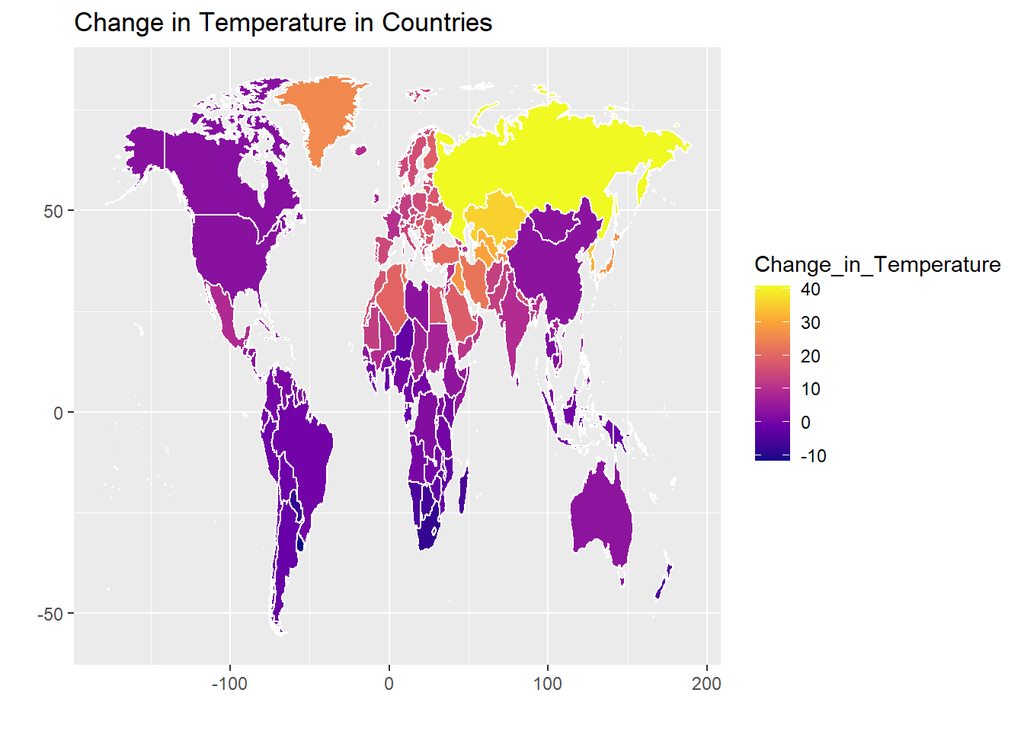

## Global Waste Generation

This bar chart helps answer which country has contributed most to climate change through waste generation (per capita). Each bar represents the average amount of waste a person generates within a country. As you can see, not all countries are listed on the chart because the average values of waste generation are combined with others within the same region, like Europe, for instance. Waste generation, in terms of climate change, is not good for the environment. Waste generation, releases a greenhouse gas that contributes to climate change. Therefore, the more waste being generated within a country/region, the more that country contributes to climate change. By looking at this bar chart, you are able to compare the difference between the average waste generated between countries when referring to the numbers above each bar. You are also able to easily see which contries generated the most and least waste. To answer the question by looking at the chart, the United States has contributed the most to waste generation (0.74) and Indonesia has contribued the least (0.05).

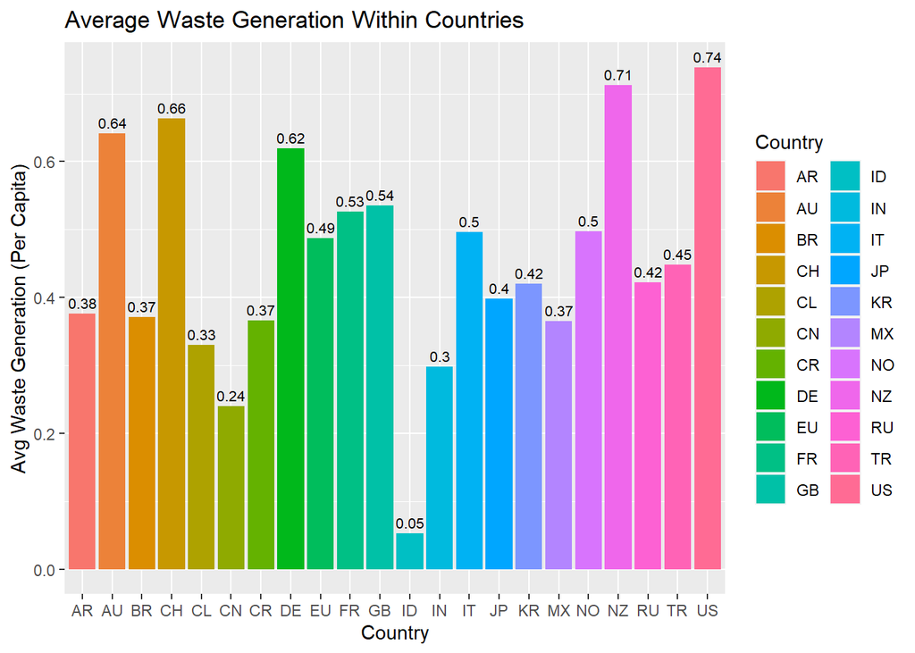

## Correlation between waste recycling rate and global warming

We are interested in whether particularly how has the waste factor contribute to global warming. We hypothesize that the higher the recycled waste will correlate *negatively* with the change in temperature. This scatter plot shows the correlation between the average percent recycled waste vs average temperature change in a small set of countries in Europe. As the regression line has shown, the higher the percent recycled waste is *positively* correlate to the land temperature change. This is not what we expected and this could due the sample size is too small to make a good projection.

[interactive chart not shown]